# Cellular Performance Gauge — Report

Patient ANON_BREAST_13y · Test 2026-06-27 · 2026-06-27 · chain CPG_v1_primary_plus_confirmation

**Context (read alongside, never used in scoring):** age 58 · sex F · substrate whole_blood · family history none provided

## How to read this report (for the clinician and for a future AI)

CPG asks **two detection questions** — the two modes below. It answers each with two independent deconvolvers (legacy and NILC), on whichever substrate it is given (whole blood or cfDNA plasma), and adds a confirmation chain — derived global-departure adjudication, and trajectory across visits — whenever a pattern flags or a prior draw exists. A finding in either mode is worth attention; they answer different questions.

**Two deconvolvers, by design.** A blood sample is a mixture of dozens of cell types, so before anything else CPG has to estimate how much of each is present from the bulk methylation signal — a step called **deconvolution**. CPG runs this twice, with two methods built on different mathematics. The first (**legacy**, a constrained fit) is deliberately conservative: it will not report a cell unless the evidence forces it, so faint traces are floored to zero. That gives the **reliable composition** the rest of the report stands on. The second (**NILC**, adapted from the variance-weighted technique used to clean cosmic-microwave-background maps) is deliberately sensitive: it surfaces the faint shed signal the conservative fit suppresses. Where the two agree, confidence is high. Where they disagree, the disagreement is itself information — it is how a cell quietly shedding into blood gets caught early. Two lenses, each catching what the other can miss; neither alone would be as trustworthy as the pair.

**Mode 1 — Architectural concordance.** Each cell gets an **A-score**, a derived measure of how far its methylation architecture has walked from its healthy floor (A ≈ 1.0 by derivation; no cohort, no population). The pattern of those departures across cells is compared to each disease's signature by **scale-invariant cosine** — the angle between the patient's departure vector and the signature, so absolute magnitudes never need converting and nothing standardizes the patient against a population. This is the workhorse for field-effect and systemic disease, whose signal sits in the **abundant immune cells we can score cleanly**. A-scores are produced on whichever substrate is run: in whole blood, the immune and shed cells abundant enough to score; in cfDNA plasma, the run-everything pass scores every class the plasma actually carries. It reports **resemblance, not a probability**: v1 can recognize that a pattern looks like a template learned in validation cohorts; the calibrated magnitude that would turn resemblance into "this stage of this disease" only accrues from real patients over years, in our own derived A-units. Direction agreement is the coarse gate; cosine shape is the fine discriminator (it is what separates aging from Alzheimer's — same direction, different proportions).

**What separates this from a plain cell-of-origin readout:** listing which cells are present in plasma is table stakes. CPG measures how far each present cell's methylation architecture has departed from its own derived healthy floor — a physics-derived scale with no cohort and no population — and reads the pattern of those departures against disease signatures. The presence is the easy part; the architectural departure is the measurement.

**Mode 2 — Cell-of-origin presence.** A different test: a cell **circulating in blood that should not be there**. The one presence that is alarming by itself is a **blood-brain-barrier cell** (cortical neuron, glia, oligodendrocyte) — it crossed a physical barrier to be in blood, so quantity and A-score are irrelevant to the call; refer. Every other cell that can shed into blood — epithelial/secretory (breast, prostate, colon), cycling — does so at a normal baseline. **Detecting them is not abnormal**; we detect and, when abundant enough, score them routinely. So their presence is normal composition (see the composition table), and the A-score is the discriminator only when the cell is abundant enough to score. A cell at ~1% is ~99% blood, so its architecture cannot be scored from the bulk signal — we detect such a cell's presence but do not assign it an A-score. The sensitive front end is the unconstrained NILC deconvolver, which surfaces faint shed signal the constrained fit floors to zero.

**Confidence intervals** on every A-score are derived from the atlas's own MCMC posteriors (the 8 per-class per-CpG brightness tables), not from a cohort. **Trajectory:** this report stores the patient's derived departure vector as a baseline; a second or third test compares drift toward a signature's angle, which is a far stronger signal than any single snapshot.

## Mode 1 — Architectural concordance

[output not shown]

## Mode 2 — Cell-of-origin presence

[output not shown]

## Disease cards (clinical interpretation layer)

The immune-atlas card is the universal baseline and always reports. Disease-specific cards render their clinical claim and limits when stage 8 flags their disease. Cards interpret the architectural A-scores; they flag and refer, they do not diagnose.

### immune-atlas v2.0 · universal_baseline_card

Reference basis: universal baseline — always reported

Universal first-pass immune-class baseline. Returns the immune-class A-score with its 95% measurement range, each immune cell's own A-score departure from its derived healthy floor, and where the patient sits on the physics-derived tier scale. Derived floor, no cohort, no population reference. It flags and refers; it does not return a disease verdict.

**Card limits:** The magnitude bands are not yet patient-calibrated; this card reports architectural state and flags, it does not diagnose.; Sex, age, and smoking shift the immune baseline and are reported as clinical context for the doctor to weigh, not subtracted from the signal — subtracting them would risk removing real architectural signal. (A current smoker's immune reading, for example, can resemble inflammation.); Cells too dilute to read their own signal are reported as present-only, without an A-score.

## Cell-level architectural departure (the A-score readout — every cell found in blood)

Fixed reference scale — read each cell's A-score below against this ruler. It carries no patient data.

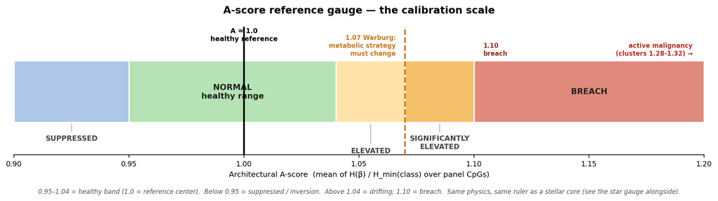

**Same ruler, a star (AstroGenetics companion)**

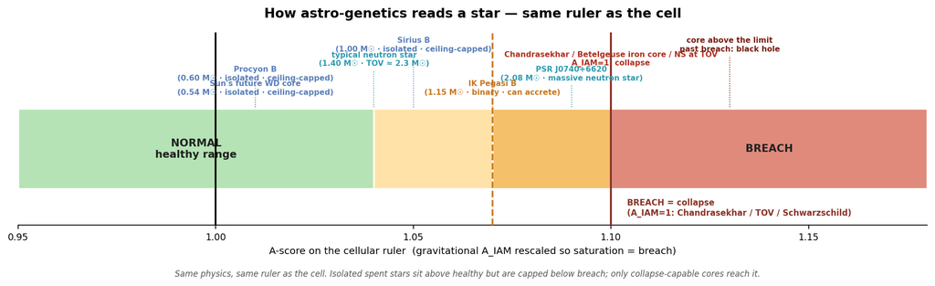

## Reading the result

A cell has to make up enough of the sample for its own methylation signal to rise above the background mixture before it can be scored; those cells get an A-score against their derived healthy floor. A cell diluted below that (~1% of blood, ~99% background) is still detected and reported (Mode 2), just not assigned an A-score. Healthy cells land at A≈1.0 when the patient beta is on the atlas scale. Mode 2 flags blood-brain-barrier cells only; epithelial, cycling and other shed cells in blood are normal and are not flagged. The resemblance bands are not yet magnitude-calibrated — that accrues from real patients in our own derived units. This report flags and refers; it does not diagnose.

**Machine-readable snapshot (for a future AI)**

[output not shown]

[output not shown]

CPG v1 · two detection modes · two deconvolvers (legacy + NILC) · whole blood + cfDNA · derived A-score, no cohort · MCMC-derived CI · matched-filter + trajectory confirmation · flags and refers, not diagnostic